# Portrait des ménages et de leur logement

Curbcut

# 4.1.1.1 Répartition ménages selon mode d’occupation

*Source: Statistique Canada, Recensement de la population de 2021, analyse et traitement des données par Curbcut*

Ces tendances révèlent un changement structurel dans la dynamique du marché résidentiel à Laval. Entre 2006 et 2011, l’essentiel de la croissance des ménages a été tiré par les propriétaires, reflétant probablement un contexte économique favorable à l’accès à la propriété, avec une augmentation nette de la proportion de ménages propriétaires. En revanche, la période 2016 à 2021 marque un renversement de tendance. Durant ces années, bien que le nombre total de ménages ait continué de croître, cette croissance semble avoir été largement absorbée par les locataires, indiquant un changement dans les conditions économiques ou les préférences résidentielles.

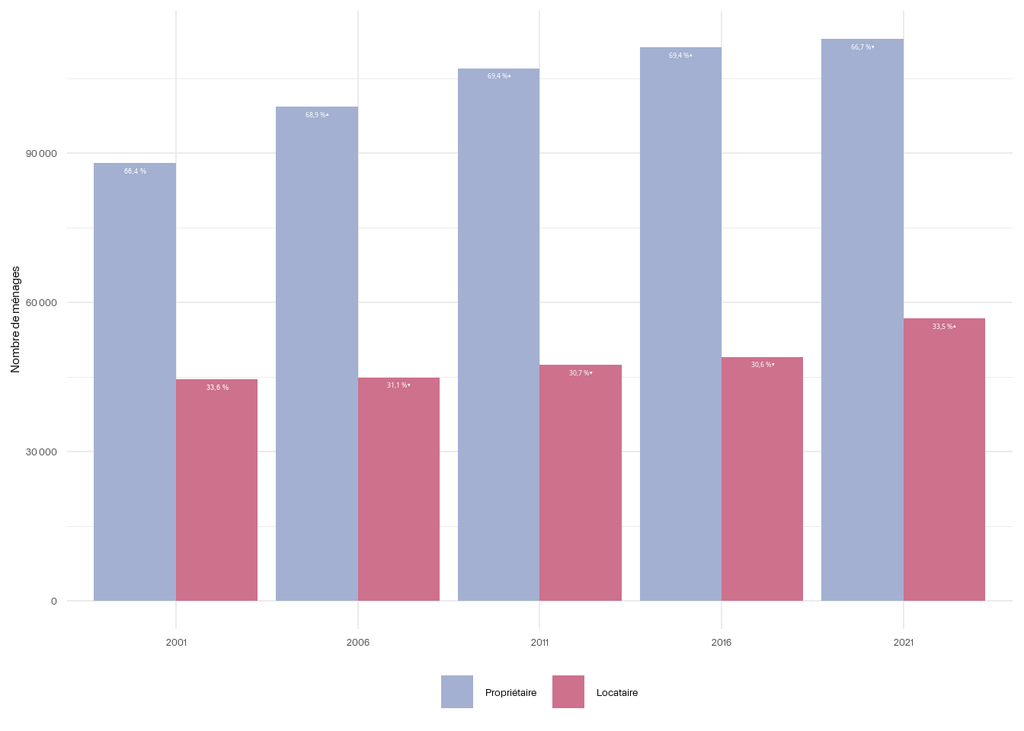

Proportion de ménages propriétaires et locataires

ENCADRÉ: La corrélation linéaire est positive et très forte (0.99) entre le pourcentage de ménages propriétaires et la proportion de maisons unifamiliales, jumelées ou en rangée, indiquant une relation étroite entre la typologie des habitations et la propriété dans les districts lavallois. Dans les districts où il y a un pourcentage plus élevé de maisons unifamiliales, jumelées ou en rangée, on observe également un pourcentage plus élevé de ménages propriétaires.

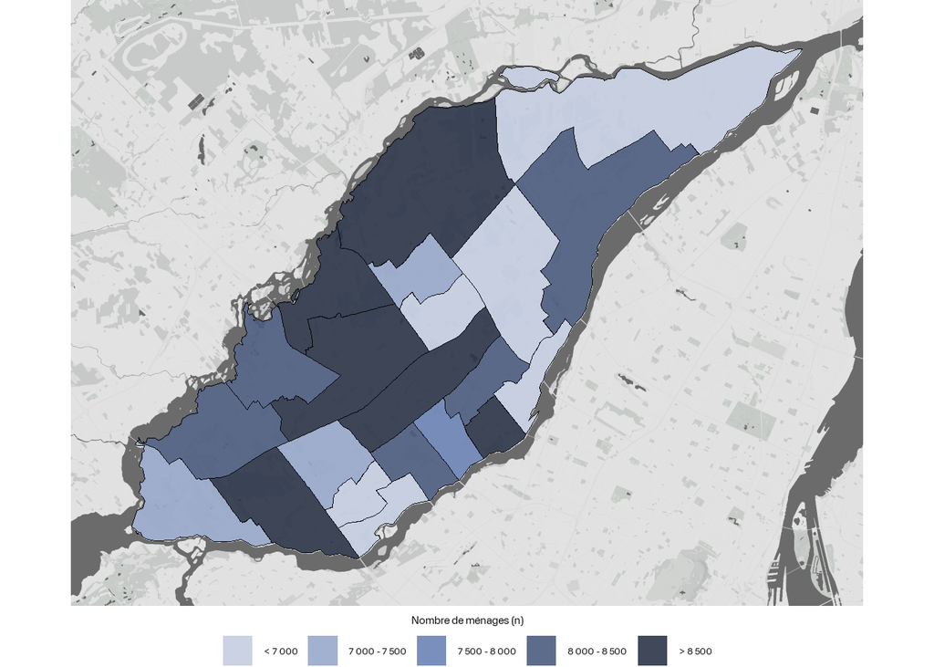

Nombre total de ménages par district électoral

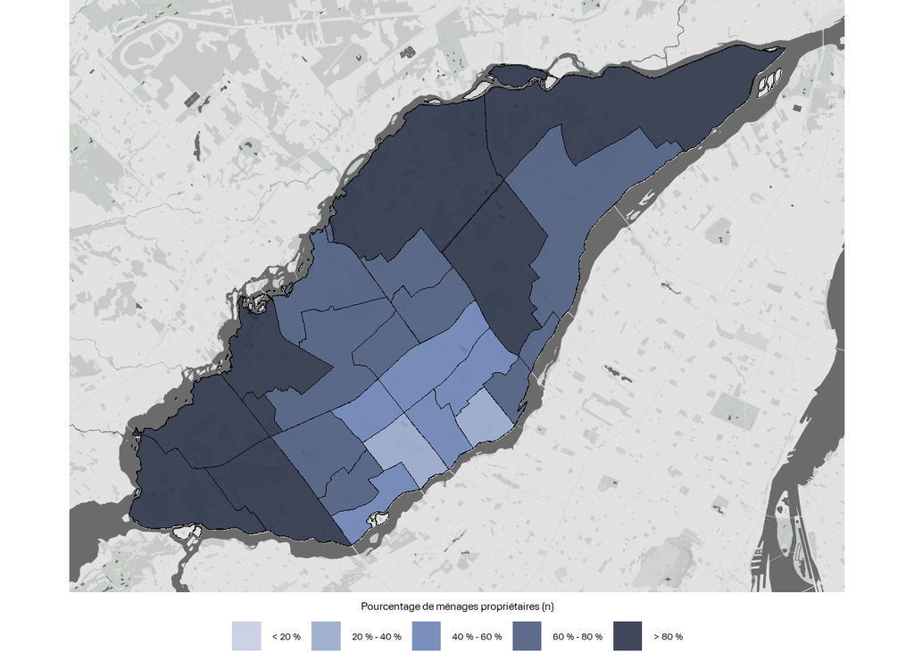

Pourcentage de ménages propriétaires, par district électoral

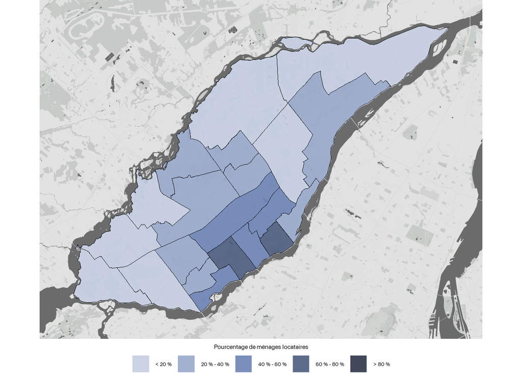

Pourcentage de ménages locataires, par district électoral